# HW#2 Exploration

Author

Mariam Garcia

Published

February 8, 2024

### Part 2a

- Wrangling
- Tidying
- Visualize (3 plots)

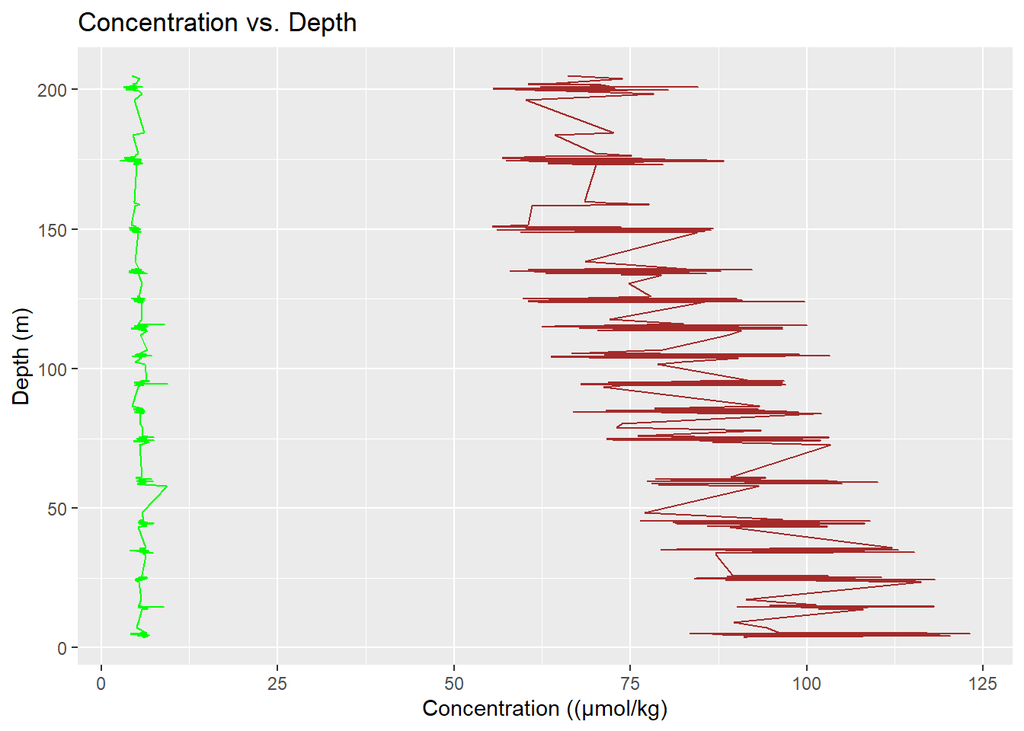

```r
##~~~~~~~~~~~~~~~~~~~~~~~~~~~~~~~~~~~~~~~~~~~~~~~~~~~~~~~~~~~~~~~~~~~~~~~~~~~~~~
##                                    Setup                                 ----
##~~~~~~~~~~~~~~~~~~~~~~~~~~~~~~~~~~~~~~~~~~~~~~~~~~~~~~~~~~~~~~~~~~~~~~~~~~~~~~

#.........................load libraries.........................
library(tidyverse)
library(showtext)
library(here)
library(patchwork)
#..........................import data...........................
nutrient_data <- read_csv(here::here('data','HOT_Bottle_ALOHA.csv'))

##~~~~~~~~~~~~~~~~~~~~~~~~~~~~~~~~~~~~~~~~~~~~~~~~~~~~~~~~~~~~~~~~~~~~~~~~~~~~~~
##                          Data wrangling / cleaning                       ----
##~~~~~~~~~~~~~~~~~~~~~~~~~~~~~~~~~~~~~~~~~~~~~~~~~~~~~~~~~~~~~~~~~~~~~~~~~~~~~~

# only keeping variables of interest(depth, chlorophyll, oxygen, dissolved organic nitrogen )

nutrient_clean <- nutrient_data %>%
  select(botid_HOT,time,doc_bottle_hot,don_bottle_hot,depth,chl_bottle_hot, botid_HOT,ph_bottle_hot) %>% # selecting columns of interest
  na.omit() %>% # removing NAs
  filter(depth <= 2000) %>% # only keeping observations with depth less than or equal to 3000 m below sea level
  rename(bottle_id = botid_HOT,
         dissolved_c = doc_bottle_hot,
         dissolved_n = don_bottle_hot,
         ph = ph_bottle_hot,
         chlorophyll = chl_bottle_hot)



##~~~~~~~~~~~~~~~~~~~~~~~~~~~~~~~~~~~~~~~~~~~~~~~~~~~~~~~~~~~~~~~~~~~~~~~~~~~~~~
##                             Data visualization                           ----
##~~~~~~~~~~~~~~~~~~~~~~~~~~~~~~~~~~~~~~~~~~~~~~~~~~~~~~~~~~~~~~~~~~~~~~~~~~~~~~
# Line graph with different depth profiles
nutrient_clean %>%
  ggplot() +
  geom_line(aes(x = depth, y = dissolved_c), color = 'brown')+
  geom_line(aes(x = depth, y = dissolved_n), color = 'green')+
  coord_flip()+
  labs(x = 'Depth (m)',
       y= 'Concentration ((μmol/kg)',
       title = 'Concentration vs. Depth')
```

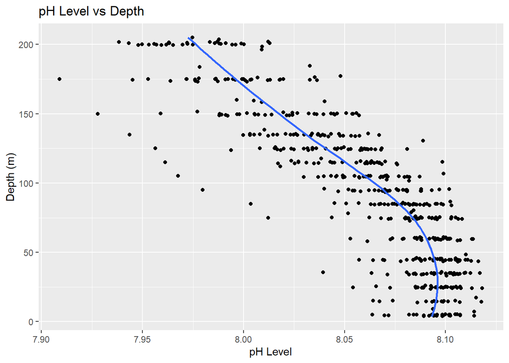

```r
# jitter plot with line of best fit

nutrient_clean %>%
  ggplot(aes(x = depth, y = ph))+
  geom_jitter()+
  geom_smooth(se = FALSE)+
  coord_flip()+
  labs(x = 'Depth (m)',
       y = 'pH Level',
       title = 'pH Level vs Depth')
```

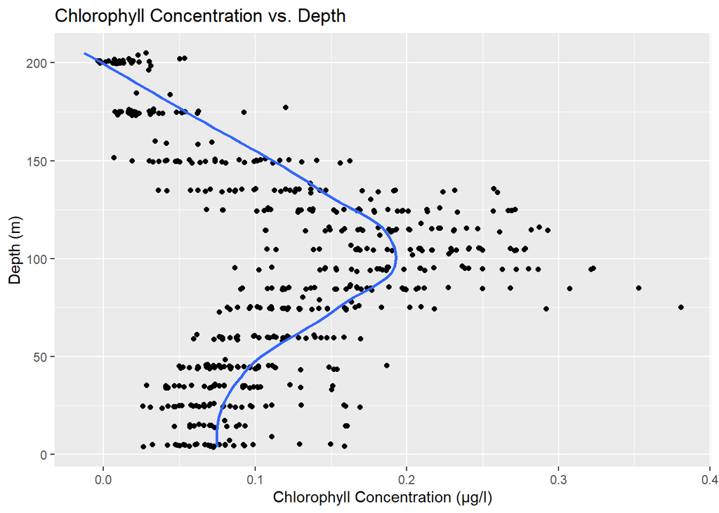

```r
# scatter plot showing relationship between concentration of chlorophyll and depth

nutrient_clean %>%
  ggplot(aes(x = depth, y = chlorophyll)) +
  geom_jitter()+
  coord_flip()+
  geom_smooth(se = FALSE)+
  labs(x = 'Depth (m)',
       y = 'Chlorophyll Concentration (µg/l)',
       title = 'Chlorophyll Concentration vs. Depth')
```

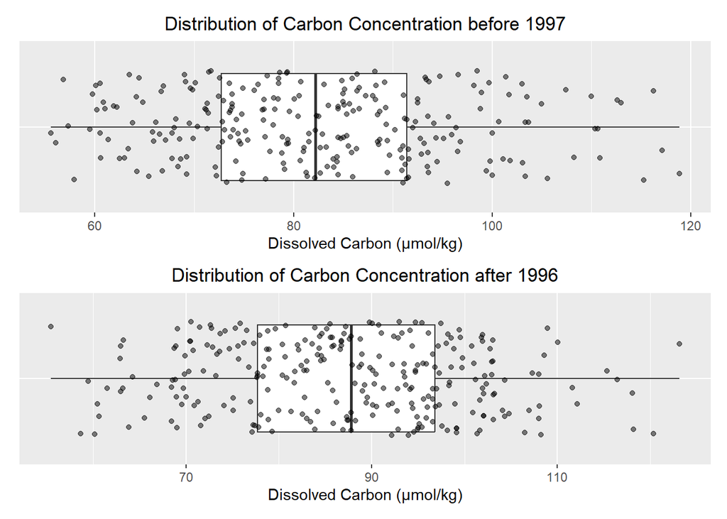

```r
# box plot with carbon and nitrogen

box_c_96 <- nutrient_clean %>%
  filter(time < as.POSIXct("1996-06-26")) %>%
  ggplot()+
  geom_boxplot(aes(x = "",dissolved_c))+
  geom_jitter(aes(x = "", dissolved_c), alpha = 0.5)+
  theme(
    axis.title.y = element_blank(),
    axis.text.y = element_blank(),
    axis.ticks.y = element_blank(),
    plot.title = element_text(hjust = 0.5)
  )+
   labs(y = 'Dissolved Carbon (μmol/kg)',
        title = 'Distribution of Carbon Concentration before 1997')+
  coord_flip()

box_c_98 <- nutrient_clean %>%
  filter(time > as.POSIXct("1996-06-26")) %>%
  ggplot()+
  geom_boxplot(aes(x = "",dissolved_c))+
  geom_jitter(aes(x = "", dissolved_c), alpha = 0.5)+
  theme(
    axis.title.y = element_blank(),
    axis.text.y = element_blank(),
    axis.ticks.y = element_blank(),
    plot.title = element_text(hjust = 0.5)
  )+
  labs(y = 'Dissolved Carbon (μmol/kg)',
       title = 'Distribution of Carbon Concentration after 1996')+
  coord_flip()

box_c_96/box_c_98
```

### Part 2b

- **1.** What have you learned about your data? Have any potentially interesting patterns emerged? **(5-8 sentences)**

I learned that my dataset has various different categories of nutrient concentrations, there are different types of observations of Nitrogen, Carbon, etc. I noticed with the `geom_jitter()` graph of chlorophyll and depth that the concentration of chlorophyll is at its peak 100 m below sea level. I would have expected a different outcome as I assumed that sunlight may not have been absorbed at that given depth. I noticed that plotting Nitrogen and Carbon together may not be ideal as their scales are different, so I was not able to see significant jumps or changes. I also noticed that a significant amount of rows did not contain data once I used `na.omit()` as my observations went from nearly 98,000 to around 500 observations.

- **2.** In HW #1, you outlined some questions that you wanted to answer using these data. Have you made any strides towards answering those questions? If yes, how so? If no, what next steps do you need to take (e.g. I need to create X plot type, I still need to track down Y data, I need to restructure existing data so that you can visualize it in Z ways, etc.)? **(8-12 sentences)**

I initially wanted to visualize the relationship of depth on the concentration of chlorophyll. I feel like I still am missing components of data wrangling that could maybe help visualize the relationship better. I want to find a way to scale the graph appropriately in a way that I am able to see change in concentration of dissolved Nitrogen as clearly and efficiently as dissolved Carbon. I am stuck on finding a way to facet wrap as they’re their own column. Each observation is unique, but the depth of the measurements vary. I need to gain a better understanding of the metadata or reach out for clarification as I am still confused on the meaning behind certain variables. I need to make a density plot comparing Nitrogen and Carbon but I can’t seem to get it right as they’re both observed variables. I need to re-visit the visualization aspect or consult with a classmate on a different approach. I don’t think my primary visualizations answer the question I have in mind as well and aesthetically pleasing as I envisioned it to be. I need to revisit the `From Data to Viz` website and re-evaluate the variables and take it step by step in classifying each one.

- **3.** What challenges do you foresee encountering with your data? These can be data wrangling and / or visualization challenges. **(4-6 sentences)**

I am a bit uneasy of the thought of not truly knowing what each variable stands for because it’ll definitely play a role in how I understand my data. I think wrangling my data in a way that makes comprehensive sense and logic flow will be a challenge. I want to answer more than one question but I think it’ll be challenging doing so given that there is no `nutrient type` column to facet wrap. I want to be creative as to how I present my findings.

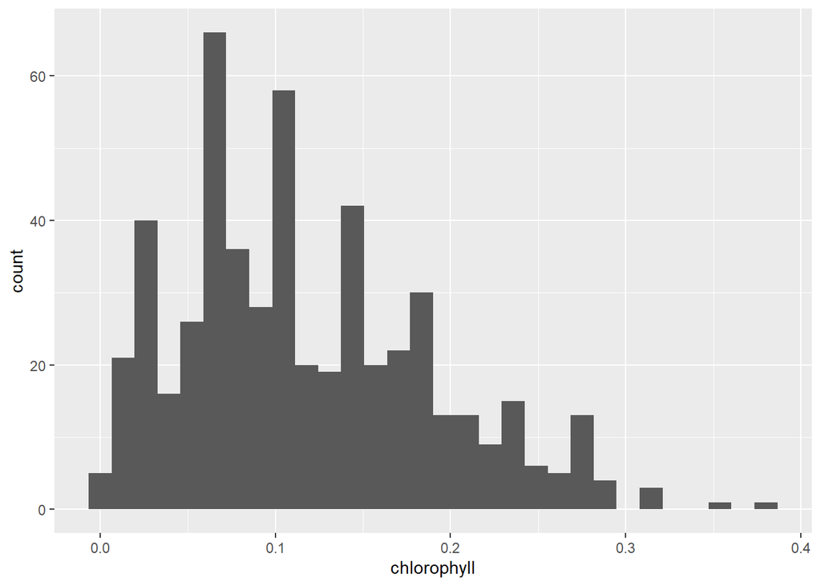

```r
nutrient_clean %>%
  ggplot() +
  geom_histogram(aes(x = chlorophyll))
```